# Avaliação 2 - Valor: 33 pontos

Introdução à Ciência de Dados - 2025  
Bacharelado em Administração

Autores

Alexia luiza

Caroline Lopes

Arthur Henrique

Gabriel Rezene

Data de Publicação

18 de junho de 2025

## Questão 1

**a)**

```r
prob_sinistro <- 0.01
indenizacao_sinistro <- 150000

premio_puro <- prob_sinistro * indenizacao_sinistro


print(premio_puro)
```

```
[1] 1500
```

**b)**

```r
# Margem alvo sobre o prêmio puro
margem <- 0.25

# Cálculo do prêmio comercial
premio_comercial <- premio_puro * (1 + margem)

# Exibindo o resultado
print(premio_comercial)
```

```
[1] 1875
```

**c)**

Simulação dos custos médios com 10 residências seguradas:

```r
# Valores
custo_sem_sinistro <- 0
custo_com_sinistro <- 150000
prob_nao_sinistro <- 0.99
prob_sinistro <- 0.01

## fixa a semente para reprodutibilidade
set.seed(2025)

## simula o custo para 10 residências seguradas
custos_10 <- sample(
  c(custo_sem_sinistro, custo_com_sinistro),        # preencha com os dois valores de custos possíveis: sem sinistro e com sinistro
  size = 10,          # número total de residências a serem simuladas
  replace = TRUE,       # indique se a amostragem será com reposição
  prob = c(prob_nao_sinistro, prob_sinistro)  # probabilidades de cada um dos dois resultados (sinistro e não sinistro)
  )

## estimativa do custo médio por apólice com 10 residências seguradas
mean(custos_10)         # função para calcular a média do vetor simulado
```

```
[1] 0
```

Simulação dos custos médios com 100 residências seguradas:

```r
set.seed(2025) # Mantendo a mesma semente para comparabilidade, se desejar. Ou uma nova semente.

custos_100 <- sample(
  c(custo_sem_sinistro, custo_com_sinistro),
  size = 100,
  replace = TRUE,
  prob = c(prob_nao_sinistro, prob_sinistro)
)
mean(custos_100)
```

```
[1] 4500
```

Simulação dos custos médios com 1000 residências seguradas:

```r
set.seed(2025) # Mantendo a mesma semente.
custos_1000 <- sample(
  c(custo_sem_sinistro, custo_com_sinistro),
  size = 1000,
  replace = TRUE,
  prob = c(prob_nao_sinistro, prob_sinistro)
)
mean(custos_1000)
```

```
[1] 1500
```

**d)**

A Lei dos Grandes Números afirma que, com o aumento do número de observações (como o número de apólices), a média dos resultados tende a se aproximar do valor esperado teórico (prêmio puro). No setor de seguros, isso permite:

Previsibilidade do risco: Mesmo com riscos individuais incertos, grandes carteiras tornam os custos totais mais previsíveis.

Precificação adequada: As seguradoras calculam prêmios justos e sustentáveis com base nessa previsibilidade.

Viabilidade econômica: A LGN torna possível transformar incerteza individual em previsibilidade coletiva, sustentando o modelo de negócio do seguro.

**e)**

A franquia reduz o valor pago pela seguradora em cada sinistro. Exemplo: se o prejuízo é de R$ 150 mil e a franquia é R$ 50 mil, a seguradora paga R$ 100 mil.

Essa redução impacta o custo esperado por apólice, que passa a ser:

1% × R$ 100.000 = R$ 1.000

Com isso, a seguradora pode:

1. Cobrar prêmios menores e ser mais competitiva;
2. Manter o prêmio e aumentar sua margem de lucro.

Além disso, a franquia incentiva o segurado a cuidar melhor da propriedade, pois ele arca com parte do prejuízo.

## Questão 2

**a)**

```r
# Valores
media <- 6.5
desvio_padrao <- 1.8

# Probabilidade de o tempo de entrega ser superior a 8 dias

prob_maior_8_dias <- pnorm(8, mean = media, sd = desvio_padrao, lower.tail = FALSE)

# Exibindo o resultado

print(prob_maior_8_dias)
```

```
[1] 0.2023284
```

**b)**

```r
# prazo que cobre 90% dos casos
prazo_90_porcento <- qnorm(0.90, mean = media, sd = desvio_padrao)

# Exibindo o resultado
print(prazo_90_porcento)
```

```
[1] 8.806793
```

**c)**

```r
# para a prazo de 7 dias

prob_prazo_7_dias_cumprido <- pnorm(7, mean = media, sd = desvio_padrao)

# Exibindo o resultado
print(prob_prazo_7_dias_cumprido)
```

```
[1] 0.6094085
```

## Questão 3

**a)**

```r
# Valores
media <- 18500
desvio_padrao <- 2300
vendas_loja <- 21800

# Cálculo do score Z
score_z <- (vendas_loja - media) / desvio_padrao

# Exibindo o resultado
print(score_z)
```

```
[1] 1.434783
```

**b)**

```r
# Cálculo da probabilidade acumulada (percentil) usando o score Z
# pnorm(q, mean = 0, sd = 1) para a distribuição normal padrão
prob_acumulada <- pnorm(score_z, mean = 0, sd = 1)

# Exibindo o resultado
print(prob_acumulada)
```

```
[1] 0.9243255
```

**c)**

Sim, esse dia foi excepcional para essa loja.

Como o percentil de vendas da loja é maior que 90%, ela se encontra dentro do grupo das 10% melhores vendas do dia. O percentual de 92,43% indica que a loja superou 92,43% das outras lojas em termos de vendas naquele dia, o que a coloca na faixa de desempenho excepcional definida pela empresa.

## Questão 4

**a)**

```r
# Dados do problema
media_retorno <- 0.011  # 1.1%
desvio_padrao <- 0.042  # 4.2%
valor_investido <- 400000 # R$ 400.000

# Cálculo
quantil_z_99 <- qnorm(0.01)
```

Cálculo do VaR 99% percentual:

```r
var_percentual_99 <- media_retorno + (quantil_z_99 * desvio_padrao)

print(var_percentual_99)
```

```
[1] -0.08670661
```

```r
var_monetario_99 <- valor_investido * var_percentual_99

print(var_monetario_99)
```

```
[1] -34682.64
```

**b)**

O VaR de 99% monetário significa que há apenas 1% de chance de que o portfólio sofra uma perda igual ou superior ao valor de 34682.64 (o valor calculado acima) em um único mês. Em 99% dos meses, a perda esperada será menor do que esse valor.

**c)**

Assimetria (Skewness): Retornos financeiros costumam ter assimetria negativa, ou seja, perdas grandes são mais prováveis do que ganhos grandes. A distribuição normal, sendo simétrica, não representa de forma adequada tal realidade, podendo desprezar o risco de perdas.

Curtose (Caudas Pesadas): Retornos reais frequentemente apresentam caudas (extremos) mais pesadas do que a normal. Isso significa que eventos extremos (grandes perdas ou ganhos) são mais comuns do que o modelo normal prevê, levando a uma subestimação do risco pelo VaR.

## Questão 5

- A
- B
- C
- D
- E

Por que as demais estão erradas?

A - Incorreta: O gráfico não ranqueia os países só pela taxa (pontinhos roxos). Ele parece seguir mais o número total (barras laranja). Santa Lúcia tem taxa baixa, mas a primeira parte da frase está errada.

B - Incorreta: Essa alternativa erra feio ao culpar a vítima, sugerindo que mulheres devem “evitar riscos”. Organismos como ONU e CEPAL focam na responsabilidade do agressor e na proteção, não na restrição da liberdade feminina.

C - Incorreta: Brasil, México e Argentina têm muitos casos em números absolutos, mas suas taxas (pontinhos roxos) não são as maiores. Países como Honduras, El Salvador e Trinidad e Tobago é que se destacam nas taxas.

E - Incorreta: A frase está confusa e errada. O Brasil está alto em número absoluto, não taxa. E Honduras tem uma das maiores taxas relativas, não “menos ocorrências” que o Brasil. Os dados estão invertidos.

## Questão 6

**a)**

```r
dados_precos <- c("PETR4.SA", "WEGE3.SA") %>%
  tq_get(from = "2024-01-01") %>%
  select(symbol, date, close) %>%
  pivot_wider(names_from = symbol, values_from = close) %>%
  rename(petrobras = "PETR4.SA", weg = "WEGE3.SA")

head(dados_precos)
```

```
# A tibble: 6 × 3
  date       petrobras   weg
  <date>         <dbl> <dbl>
1 2024-01-02      37.8  36.6
2 2024-01-03      39.0  36.8
3 2024-01-04      38.6  36.4
4 2024-01-05      38.7  36.0
5 2024-01-08      38.4  36.1
6 2024-01-09      38.1  35.2
```

**b.1)**

```r
# cálculo dos retornos logarítmicos
dados_ret <- dados_precos %>%
# a função `mutate()` adiciona as colunas de retornos
mutate(ret_petrobras = log(petrobras / lag(petrobras)),
     ret_weg       = log(weg       / lag(weg))) %>%
# drop_na remove a linha com retorno faltante (NA)
drop_na()

# exibição das primeiras linhas
head(dados_ret)
```

```
# A tibble: 6 × 5
  date       petrobras   weg ret_petrobras  ret_weg
  <date>         <dbl> <dbl>         <dbl>    <dbl>
1 2024-01-03      39.0  36.8       0.0308   0.00763
2 2024-01-04      38.6  36.4      -0.00851 -0.0134
3 2024-01-05      38.7  36.0       0.00233 -0.0108
4 2024-01-08      38.4  36.1      -0.00752  0.00250
5 2024-01-09      38.1  35.2      -0.00862 -0.0250
6 2024-01-10      37.8  35.3      -0.00923  0.00426
```

**b.2)**

```r
correlacao_retornos <- cor(dados_ret$ret_petrobras, dados_ret$ret_weg)

print(correlacao_retornos)
```

```
[1] 0.1371311
```

**b.3)**

```r
resultados_analise <- dados_ret %>%
  summarize(
    # Métricas para PETR4.SA
    min_ret_petro   = min(ret_petrobras),
    max_ret_petro   = max(ret_petrobras),
    mean_ret_petro  = mean(ret_petrobras),
    sd_ret_petro    = sd(ret_petrobras),

    # Métricas para WEGE3.SA
    min_ret_weg     = min(ret_weg),
    max_ret_weg     = max(ret_weg),
    mean_ret_weg    = mean(ret_weg),
    sd_ret_weg      = sd(ret_weg),

    # Correlação entre os retornos
    correlacao_petro_weg = cor(ret_petrobras, ret_weg, use = "complete.obs")
  )

# Exibir os resultados de forma mais legível
print(as.data.frame(lapply(resultados_analise, function(x) round(x, 4))))
```

```
  min_ret_petro max_ret_petro mean_ret_petro sd_ret_petro min_ret_weg
1       -0.0958        0.0701         -4e-04       0.0169     -0.1227
  max_ret_weg mean_ret_weg sd_ret_weg correlacao_petro_weg
1      0.0995        3e-04     0.0181               0.1371
```

**c)**

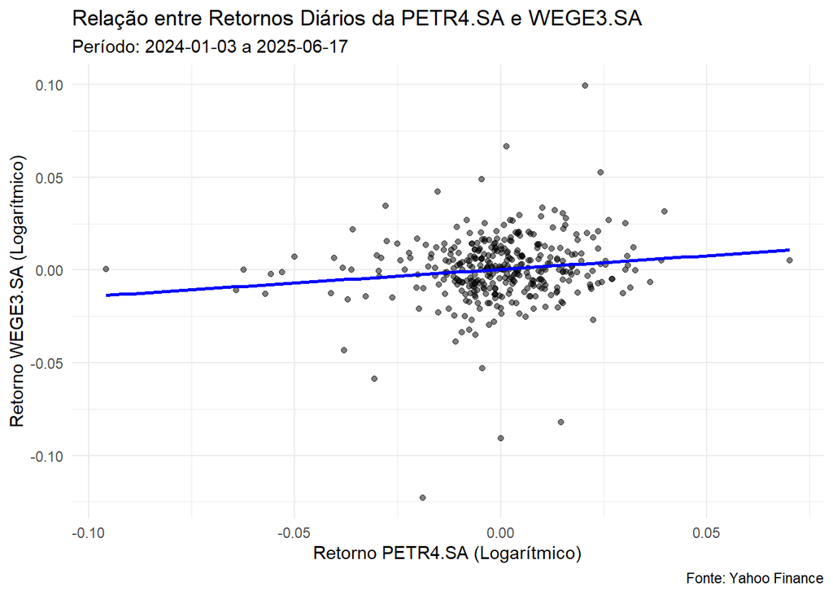

```r
ggplot(dados_ret, aes(x = ret_petrobras, y = ret_weg)) +
  geom_point(alpha = 0.5) +
  geom_smooth(method = "lm", se = FALSE, color = "blue") +

  labs(
    title = "Relação entre Retornos Diários da PETR4.SA e WEGE3.SA",
    subtitle = paste0("Período: ", min(dados_ret$date), " a ", max(dados_ret$date)),
    x = "Retorno PETR4.SA (Logarítmico)",
    y = "Retorno WEGE3.SA (Logarítmico)",
    caption = "Fonte: Yahoo Finance"
  ) +
  theme_minimal()
```

**Interpretação:**

Se a correlação_retornos for positiva (como provavelmente será),

a nuvem de pontos tende a subir da esquerda para a direita, e a linha de regressão terá uma inclinação positiva. Isso significa que, em geral, quando o retorno da Petrobras sobe, o da Weg também tende a subir, e vice-versa. Se for negativa, a nuvem de pontos desceria.Se for perto de zero, os pontos estariam espalhados sem um padrão claro.

**d)**

Para avaliar se juntar PETR4 e WEGE3 ajuda a diversificar seus investimentos, é crucial analisar como seus desempenhos se relacionam.Se for alta e positiva, a diversificação é limitada, pois os ativos se movem juntos. Se for próxima de zero, há alguma diversificação, pois os movimentos são independentes. Se for negativa, há maior potencial de diversificação, pois os ativos tendem a se mover em direções opostas, ajudando a reduzir o risco total da carteira.